# One Way ANOVA - Analysis of Variance

Arnab Aich

## Introduction

Analysis of Variance (ANOVA) is a statistical method used to compare means across different groups by analyzing the variation within and between groups. It helps determine if there are significant differences between the means of different categories. ANOVA is used when:

- You have one or more categorical independent variables (factors) with multiple levels.
- You have a continuous dependent variable.
- You want to determine if the variation in the dependent variable is primarily due to the factor variables(between groups) or random error (within groups).
- You want to compare the means of three or more groups to determine if they are significantly different.

**Example Dataset:**

Suppose a researcher is studying the effect of three different diets on weight loss(in kgs). The researcher collects data from participants on three different diets (A, B, and C) over a month:

| Diet | Weight_Loss |
| --- | --- |
| A | 5, 6, 7, 8 |
| B | 3, 4, 5, 6, 7 |
| C | 8, 9, 7, 10, 9, 6 |

We can compare box plots for different diets to visualize the distribution of weight loss data. It also helps us comparing measures of location and spread across different groups.

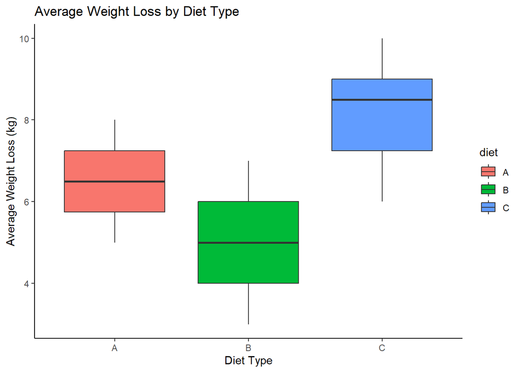

## One-Way ANOVA

One-way ANOVA is used when there is only one independent variable (Categorical) with multiple levels($k$), typiccally $k>2$. The test compares the means of the groups to determine if there is a significant difference between them. In one way anova different categories of independent variable can have different number of observations ( $n_j$ where $ j = 1,2….,k $ ).

### Mathematical Model

The mathematical model for One-Way ANOVA can be expressed as:

$$Y_{ij} = \mu + \alpha_i + \epsilon_{ij}$$

where $Y_{ij}$ is the observed value of the dependent variable for the $j$-th observation in the $i$-th group. The model assumes that the total variation in the observed data ($Y_{ij}$) can be decomposed into:

1. **Overall Mean ($\mu$)**: Represents the central location of all data points across all groups. It is the is the overall mean of the dependent variable.
2. **Group Effect ($\alpha_i$)**: It represents the effect of the $i$-th group (treatment effect or deviation from the overall mean due to belonging to group $i$). Captures the deviation of each group mean from the overall mean, indicating how different each group is from the average.
3. **Error ($\epsilon_{ij}$)**: Accounts for the random variability not explained by group differences. It is the random error term associated with the $j$-th observation in the $i$-th group, assumed to be normally distributed with a mean of 0 and constant variance $\sigma^2$.

### Explanation of Components

1. **Overall Mean ($\mu$)**:
   - This is the mean of all observations across all groups. It acts as a baseline or reference point in the model.
   - The overall mean $\mu$ gives us an understanding of the general level of the dependent variable before considering group-specific effects.
   - Mathematically, $\mu = \frac{\sum_{i=1}^{k} \sum_{j=1}^{n_i} Y_{ij}}{N}$, where $k$ is the number of groups, $n_i$ is the number of observations in the $i$-th group, and $N$ is the total number of observations.
2. **Group Effect ($\alpha_i$)**:
   - This term represents the effect of being in the $i$-th group (e.g., Diet A, Diet B, or Diet C). It measures how much the mean of the $i$-th group deviates from the overall mean.
   - If $\alpha_i$ is large, it suggests that the $i$-th group has a strong effect on the dependent variable, causing its mean to deviate significantly from the overall mean.
   - Each group effect $\alpha_i$ is constrained such that $\sum_{i=1}^{k} \alpha_i = 0$. This ensures that the group effects are measured relative to the overall mean and keeps the model balanced.
3. **Error Term ($\epsilon_{ij}$)**:
   - The error term accounts for the variability within each group that cannot be explained by the overall mean or the group effect.
   - It captures the random deviations of each individual observation from its group mean.
   - The assumption is that these errors are independent, normally distributed, and have constant variance $\sigma^2$ .
   - If the variability within groups is low, it indicates that the group means are good representations of the individual values within each group. High variability within groups can mask the differences between group means.

### Assumptions

- The dependent variable is continuous and the independent variable is categorical.
- The observations are **independent** and **Normally** distributed.
- The variances of the groups are **equal**.

### Hypotheses

- Null Hypothesis: The means of all groups are equal.

$$H_0: \mu_1 = \mu_2 = \mu_3 = \ldots = \mu_k$$

which is equivalent to: $\alpha_1 = \alpha_2 = \alpha_3 = \ldots = \alpha_k = 0$ i.e. there is no effect of the group (Diets) on the dependent variable.

- Alternative Hypothesis: At least one group mean is different.

$$H_A: \text{At least one } \mu_i \text{ is different}$$
which is equivalent to: $\text{At least one } \alpha_i \neq 0$ i.e. there is an effect of the group (Diets) on the dependent variable.

### Sum of Squares

- **Total Sum of Squares (TSS)**: Measures the total variation in the dependent variable.
  $$TSS = \sum_{i=1}^{n} (Y_{ij} - \bar{Y})^2 = n \times \text{Var}(Y)$$
  Degrees of Freedom: $DF_{Total} = n - 1$.

For the example dataset, the between groups sum of squares is calculated as: {SSB = 27.5} and $DF_{Between} = 2$

- **Within Groups Sum of Squares (SSW)**: Measures the variation within groups.
  $$SSW = \sum_{i=1}^{k} \sum_{j=1}^{n_i} (Y_{ij} - \bar{Y}_i)^2
  = \sum_{i=1} ^{k}n_i Var(\bar{Y_i})$$
  Degrees of Freedom ($DF_{Within}$) = n - k. Sum of squares within(SSW) is also known as Sum of Squares due to error or $SS_{Error}$

For the example dataset, the within groups sum of squares is calculated as: {SSW = 25.83} and $DF_{Within} = 12$

### Mean Squares

- **Mean Square Between (MSB)**: Measures the variance between group means.
  $$MSB = \frac{SSB}{DF_{Between}} = \frac{27.}{2} = 13.75.$$
  Mean square between is also known as $MS_{Treatment}$.
- **Mean Square Within (MSW)**: Measures the variance within groups.
  $$MSW = \frac{SSW}{DF_{Within}} = \frac{25.83}{12} = 2.153.$$
  Mean square within is also known as $MS_{Error}$

### Test Statistic

The ratio of the variance between groups to the variance within groups.

$$F = \frac{MSB}{MSW} = \frac{SS_{Treatment}/(k-1)}{SS_{Error}/(n-k)}$$

Under the null hypothesis:
$$F \sim F_{k-1, n-k}$$

For the example dataset, the F-statistic is calculated as: $F_{observed} = 6.387$

### Critical Value

The critical value is determined based on the significance level ($\alpha$) and the degrees of freedom for between and within groups. The critical value is determined using the F-distribution table which is given as $F_{\alpha; k-1, n-k}$.

For the example dataset, the critical value at $\alpha = 0.05$ is calculated as: $F_{crit} = F_{0.05;2,12} = 3.89$

### P-Value

The p-value is the probability of observing the test statistic (F) or more extreme values under the null hypothesis. A small p-value indicates that the observed variance between groups is significantly greater than expected by chance.
$$p-value = P(F_{k-1,n-k} > F_{observed})$$

For the example dataset, the p-value is calculated as: $P(F_{2,12} > 6.387 ) = 0.013$

### ANOVA Table Calculation

| Source of Variation | Sum of Squares | Degrees of Freedom | Mean Squares | F Value | Critical Value | P Value |
| --- | --- | --- | --- | --- | --- | --- |
| Between Groups (SSB) | 27.500 | 2 | 13.75 | 6.386 | 3.885 | 0.013 |
| Within Groups (SSW) | 25.833 | 12 | 2.153 |  |  |  |
| Total (TSS) | 53.333 | 14 |  |  |  |  |

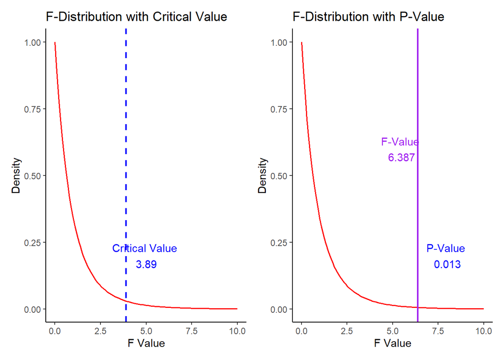

### Decision

The p-value of **0.013** is less than the significance level of 0.05. Therefore, we reject the null hypothesis and conclude that there is a significant difference between the mean weight loss of the three diets.

The F-statistic of **6.387** is greater than the critical value of **3.89**, further supporting the rejection of the null hypothesis.

## Recap

The document provides an in-depth exploration of One-Way Analysis of Variance (ANOVA), a statistical method utilized to compare the means of multiple independent groups to determine if there are statistically significant differences among them. The discussion includes:

- **Definition and Purpose:** ANOVA is defined as a method to test if there are significant differences between the means of three or more unrelated groups. It is particularly useful in scenarios where multiple groups are subjected to different treatments or conditions, and we want to ascertain if the observed effects are due to the treatments or merely by chance.
- **Assumptions:**
  - Independence of observations.
  - Normal distribution for all response values.
  - Homogeneity of variances across groups (equal variances).
- **Key Concepts:**
  - **Between-group Variability:** Reflects differences among the group means and gives an indication of the effect of the treatments.
  - **Within-group Variability:** Indicates variability within each group and is used as a baseline measure of variability (i.e., how much the members of each group differ from each other without treatment effects).
- **Steps in ANOVA:**
  1. **Calculate the overall mean** to serve as a reference point for comparing group means.
  2. **Compute the Sum of Squares Between (SSB)** which measures the total deviation of group means from the overall mean, weighted by the size of each group.
  3. **Determine the Sum of Squares Within (SSW)** which measures the deviation of individual observations from their respective group means.
  4. **Calculate Mean Squares** for between groups (MSB) and within groups (MSW) by dividing SSB and SSW by their respective degrees of freedom.
  5. **Compute the F-statistic** as the ratio of MSB to MSW to test if the group means are significantly different.
- **Interpretation of Results:** A significant F-statistic leads to the rejection of the null hypothesis, suggesting that not all group means are equal. This indicates that the treatments have a statistically significant effect on the outcome variable.

## Questions and Answers

1. **What statistical test does ANOVA provide a basis for?**
   - ANOVA provides a basis for comparing the means of three or more independent groups to see if they differ significantly.
2. **What is the null hypothesis in a one-way ANOVA?**
   - The null hypothesis states that all group means are equal.
3. **How is the F-statistic calculated in ANOVA?**
   - The F-statistic is calculated as the ratio of the Mean Square Between groups (MSB) to the Mean Square Within groups (MSW).
4. **What does it mean if the F-statistic is significant?**
   - A significant F-statistic suggests that there are significant differences among the group means, and the treatment or condition has a real effect.
5. **What are the assumptions necessary for conducting a one-way ANOVA?**
   - The assumptions include independence of observations, normality of residuals within groups, and homogeneity of variances across groups.
6. **Can ANOVA determine which specific groups differ from each other?**
   - No, ANOVA can only determine that there is a difference among the groups, not which groups differ. Post-hoc tests are needed for specific comparisons.
7. **What is meant by ‘within-group variability’ in ANOVA?**
   - Within-group variability refers to the variation seen within each group, which represents the error or noise in the data.
8. **How can the validity of ANOVA results be compromised?**
   - The validity can be compromised if any of the assumptions of ANOVA (independence, normality, homogeneity of variance) are violated.
9. **What is the role of degrees of freedom in calculating the F-statistic?**
   - Degrees of freedom are used to determine the appropriate distribution for calculating the p-value associated with the F-statistic.
10. **How should results from ANOVA be reported in a research study?**
    - Results should include the F-statistic, degrees of freedom, p-value, and a statement on whether the null hypothesis was rejected, along with a discussion of the implications of these findings.